# Reproducible Research: Peer Assessment 1

## Loading and preprocessing the data

Unzip the data

```r
unzip('activity.zip')
```

now load the CSV

```r
    data <- read.csv('activity.csv')
```

Convert the date and the interval to time.

```r
    data$date <- as.Date(data$date)
    data$time <- as.POSIXct(strptime(sprintf("%04d",data$interval), format="%H%M"))
```

Setting the locale to get day names in english

```r
    Sys.setlocale("LC_TIME", "en_US.UTF-8")
```

```
## [1] "en_US.UTF-8"
```

Getting the day of week, and creating a factor to show if the day is a weekday or weekend

```r
    data$dayOfWeek <- weekdays(data$date)
    data$daytype <- data$day != 'Saturday' & data$day != 'Sunday'
    data$daytype[data$daytype == T] <- "weekday"
    data$daytype[data$daytype == F] <- "weekend"
    data$daytype <- as.factor(data$daytype)
```

## What is mean total number of steps taken per day?

Lets aggregate the number of steps by date first:

```r
stepsByDay <- aggregate(steps ~ date, data, sum)
```

Now, lets plot the Histogram.

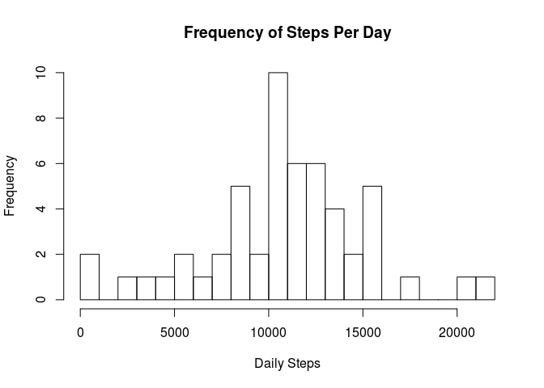

```r
hist(stepsByDay$steps, breaks=20,main="Frequency of Steps Per Day",xlab="Daily Steps")
```

This is the Mean:

```r
mean(stepsByDay$steps)
```

```
## [1] 10766
```

And the Median:

```r
median(stepsByDay$steps)
```

```
## [1] 10765
```

## What is the average daily activity pattern?

Aggregate steps by Time of Day, and take the mean number of steps

```r
meanStepsByTimeOfday <- aggregate(steps ~ time, data, mean)
```

Plot the chart

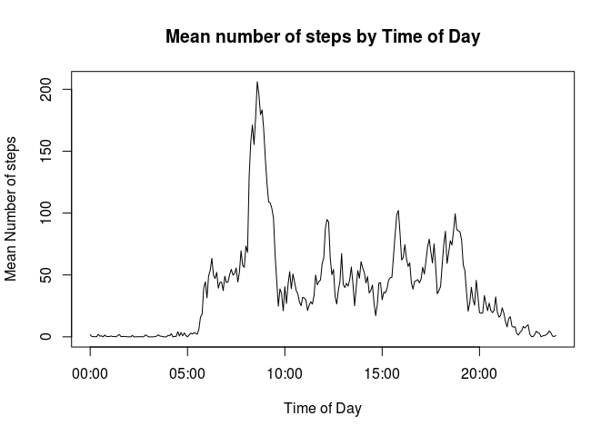

```r
    plot(meanStepsByTimeOfday$time, meanStepsByTimeOfday$steps, type="l", xlab="Time of Day", ylab="Mean Number of steps")
    title("Mean number of steps by Time of Day")
```

The hour with the biggest average number of steps is

```r
format(meanStepsByTimeOfday$time[which.max(meanStepsByTimeOfday$steps)], "%H:%M")
```

```
## [1] "08:35"
```

with the average number of steps of

```r
max(meanStepsByTimeOfday$steps)
```

```
## [1] 206.2
```

## Imputing missing values

Finding the Number of NA’s on the original Datasets.

```r
colSums(is.na(data))
```

```
##     steps      date  interval      time dayOfWeek   daytype
##      2304         0         0         0         0         0
```

Whe observe that the only column that has NA’s is the “steps” column.

Lets take the mean of each 5 minute interval and replace the missing data with the corresponding mean.

Firsts, aggregate the data so as to take the mean for each interval.

```r
meanStepsByTimeOfday <- aggregate(steps ~ time, data, mean)
```

Now, merge the aggregated data with the original data, by time

```r
merged <- merge(data, meanStepsByTimeOfday, by="time")
```

Fill the NA data by copying the values from the merged field

```r
merged$steps.x[is.na(merged$steps.x)] = merged$steps.y[is.na(merged$steps.x)]
```

Now, create a new data frame with the correct data and the same column names

```r
newdata <- data.frame(merged$time, merged$steps.x, merged$date, merged$interval)
colnames(newdata) <- c("time", "steps", "date", "interval")
```

Colculate the steps per day using the new data and plot the histogram

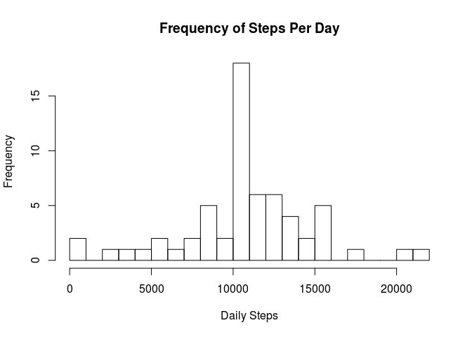

```r
stepsByDay <- aggregate(steps ~ date, newdata, sum)
hist(stepsByDay$steps, breaks=20,main="Frequency of Steps Per Day",xlab="Daily Steps")
```

Now, take the mean and the median

```r
mean(stepsByDay$steps, na.rm=T)
```

```
## [1] 10766
```

```r
median(stepsByDay$steps, na.rm=T)
```

```
## [1] 10766
```

We can see that the mean is still the same as before and the median is very close, but the frequency of days on the mean is much larger. While, on the original data, it is close to 10, on the modified data it is larger than 15.

## Are there differences in activity patterns between weekdays and weekends?

Aggregate steps by interval and the type of the day

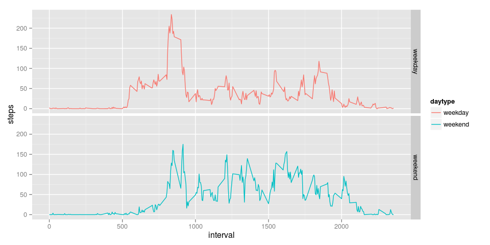

```r
library(ggplot2)

    aggregated <- aggregate(steps ~ interval + daytype, data, mean)
    qplot(interval, steps, data=aggregated, geom="line", colour=daytype) + facet_grid(daytype ~ .)
```

The pattern for weekdays and weekends look different. On weekdays, the number of steps increase earlier than on weekends. Also, the steps are more evenly distributed on weekends than on weekdays.